# STA 531 Final Paper

Eduardo Coronado

April 26th, 2019

Abstract

Early detection of the influenza outbreaks is one of the biggest challenges of outbreak surveillance systems. In this paper, a finite, homogeneous two-state Hidden Markov Model (HMM) was developed to determine the epidemic and non-epidemic dynamics influenza-like illnesses (ILI) in a differenced time series. These dynamics were further modeled via a first-order auto-regressive process based on the state, and parameters estimated via the Baum-Welch algorithm. The model was evaluated with US ILI data from 1998-2018. For more info visit - [www.github.com/ecoronado92](https://github.com/ecoronado92/Model_Influeza_Seasonal_Dynamics)

## Introduction

Every year influenza epidemics occur during winter months and result in a significant number of disease cases, deaths and public health expenses. According to the CDC, approximately 14-16% of the US population shows symptoms of influenza-like ilnesses (ILI) which causes 79,000 deaths each year. This has led public health officials to seek new ways of tracking potential outbreak situations via automated, routine influenza surveillance methods. This has traditionally been done via temporal models that have to be constantly refitted, which has practical implications, to quickly detect emerging outbreaks. Thus, it becomes especially challenging when using large datasets. Therefore, there exists a need for conceptually simpler, yet powerful methods, that can be easily automated for disease surveillance and that provide fast and accurate early detection of epidemic onsets. Therefore, the main goal of this paper is to implement a two-state Hidden Markov Model (HMM) for the early detection of influenza epidemics. HMM provides a natural way to way to model temporal data (i.e. epidemic and non-epidemic periods) by using a probability distribution for each state, and the Markov property that greatly simplifies the time dependency of the data and hidden states (Le Strat, 1). This model was tested using the US CDC’s [Influenza Surveillance network](https://www.cdc.gov/flu/weekly/overview.htm) yearly national ILI incidence rates weighted by the states’ population.

## Previous Work

Over the last 20 years various HMMs have been proposed as temporal models for influenza and ILI surveillance methods. Le Strat and Carrat were the first to apply a two-state (epidemic and non-epidemic), homogenous HMM to ILI data with each state having a normally distributed cyclical pattern over a year (i.e. 52 week cycle) (1). Following this, others have proposed using similar HMMs but with different configurations, such as Rath which use a Poisson rather than a Gaussian model to account for potential non-zero probabilities for negative rates (2). More recently, Martínez‐Beneito implemented an HMM using Bayesian Gaussian and Poisson hierarchical models on a differenced time series data (3; Conesa, 4). In 2012, Nunes further implemented a nowcasting model via a non-homogenous HMM to help shorten the time to detect early onsets of epidemics and better model the time dependency of these dynamics using Bayesian heirarchical structure (5).

## Methods

### Data

National ILI weekly incidence rates data were obtained from the US CDC’s Influenza Surveillance network via the `cdcfluview` package for the years 1997-present. For simplicity, years 1997 and 2019 were excluded from the analysis given these didn’t contain complete sets for the specified year (i.e. $T \neq 52$). Subsequently, data was preprocessed following Martínez‐Beneito ’s approach by generating a differenced time-series out of ILI rates (3). This procedure maintains the differences between epidemic versus non-epidemic dynamics as seen in Figure 1 below, with the epidemic states having higher variability, which helps simplify the model specification.

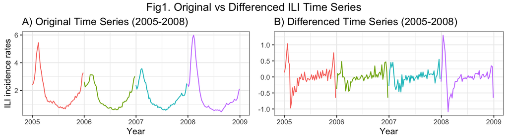

### HMM Model

The epidemic and non-epidemic trends in the differenced ILI data ($\mathbf{Y}$) were modeled via a finite, time-homogeneous two-state HMM based on Martínez‐Beneito ’s approach (3) as follows,
$$\begin{align*}
Y_{i,t} \mid Z_{i,t} = k, \psi \sim N(\mu_k, \sigma^2_{k,i}) \quad \quad i &= 1,..,N \quad \text{years with }\; N =21\\[1ex]
t &= 1,..,T \quad \text{weeks with }\; T=52\\[1ex]
k &= 0,K \quad \text{states with } \; K = 1
\end{align*}$$

$$Z_{i,t} \sim Cat (a_{0,k}, a_{1,k}) \quad \text{transition probabilities} \; a_{0,k},a_{1,k}$$
where $Z_{i,t}$ are the hidden components for epidemic ($k=1$) and non-epidemic ($k = 0$) states, $\psi$ are model parameters based on $\mu_k$, and $a_{j,k}$ are the transition probabilities between the epidemic and non-epidemic states. As an attempt to account for the epidemic dynamics having a larger variational structure than non-epidemic ones, $\mu_k$ was set to follow an AR(1) process for epidemic states such that
$$\mu_k=\begin{cases}
\rho\; Y_{i,t-1} & k = 1, \; t>1 \\
0 & k =0, \; t\geq 1; \; k=1, \; t =1
\end{cases}$$

where $\rho$ is the auto-regressive parameter in $\psi$. Similarly, $\sigma^2_{k,i}$ was set such that the variance for the epidemic state was larger than the non-epidemic one with each year being different $\sigma^2_{1,i} > \sigma^2_{0,i}$ Thus, the model is defined by the following complete data log-likelihood,
$$\ell(y,z; \psi) = \sum_{i=1}^N \bigg[ log \; f(z_{1,i}) + \sum_{t =1}^{T-1} log \; p(z_{t+1, i} \mid z_{t,i}) + \sum_{t=1}^T log \; q(y_{t,i} \mid z_{t,i}, \psi) \bigg]$$
where $f(\cdot)$ specifies the initial state at $t=1$, while $p(\cdot \mid \cdot)$ and $q(\cdot \mid \cdot)$ determine the transition and emission probabilities, respectively.

However, since the model parameters are unknown it is necessary to learn these from the data. This was achieved via the algorithm, which leverages a type of Expectation-Maximization (EM) procedure for HMMs, on the following expected complete data log-likelihood expression (Bishop, 6)
$$\begin{align*}
Q(\psi, \psi^{(p+1)}) &= \sum_{i=1}^N \bigg[ \sum_{k=0}^K E[Z_{1,i}^k] \; log \; \pi_k+ \sum_{t =1}^{T-1} \sum_{j,k=0}^K E[Z_{t,i}^j \; Z_{t+1,i}^k] log \;a_{jk} + \sum_{t=1}^T \sum_{k=0}^K E[Z_{t,i}^k] log \; N(\mu_k, \sigma_{k,i}^2)] \bigg]\\[1ex]
&= \sum_{i=1}^N \bigg[\sum_{k=0}^K \gamma_{k,i}(1) \; log \pi_k + \sum_{t =1}^{T-1} \sum_{k=0}^K \xi_{jk,i}(t) log \; a_{jk} + \sum_{t=1}^T \sum_{k=0}^K \gamma_{k,i}(t)\; log \; N(\mu_k, \sigma_{k,i}^2) \bigg]
\end{align*}$$

where $k$ is an indicator for $E[Z_{t,i}^k]$ being part of state $k^{th}$ and
$$\gamma_{k,i}(t) = E[Z_{t,i}^k] = p(Z_{t,i}^k = 1 \mid Y_{1:T, i}) \quad and \quad \xi_{jk,i}(t) =E[Z_{t,i}^j \; Z_{t+1,i}^k] = p(Z_{t,i}^j \; Z_{t+1, i}^k \mid Y_{1:T,i})$$

### HMM Training via Baum-Welch

The expectations were computed via a normalized version of the forward-backward algorithm given numerical underflow is a common problem of the regular forward-backward procedure (Bishiop, 6; Zhai, 7). In summary, it normalizes the values at each step of the forward-backward procedure such that the $\sum_{k} \hat{\alpha}_{i,k}(t) = 1$ constraint is met in the forward step only. Thus, we obtain the following expressions for the E-Step
$$\begin{align*}
\gamma_{k,i}(t) &= \frac{\hat{\alpha}_{k,i}(t) \hat{\beta}_{k,i}(t)}{\sum_{l=0}^K \hat{\alpha}_{l,i}(t) \hat{\beta}_{l,i}(t)}\\[2ex]
\xi_{jk,i}(t) &= \frac{\gamma_{j,i}(t) \;a_{jk} \;q(y_{t+1,i} \mid z_{t+1, i} = k)\; \eta_{t+1,i} \;\hat{\beta}_{k,i}(t+1) }{\hat{\beta}_{j,i}(t)}
\end{align*}$$

where $\hat{\alpha}_{k,i}(t)$ and $\hat{\beta}_{k,i}(t)$ are the normalized $\alpha, \beta$ quantities, and $\eta_{t,i} = \frac{1}{\sum_{k=0}^K \alpha_{k,i}(t)}$ is the normalizing constant computed at each forward step ( this constant cancels out when calculating $\gamma_{k,i}(t)$)

Subsequently, the updates were determined by finding the maximum likelihood estimates (MLEs) for $\rho$, $\pi_k$ (initial states), $a_{jk}$, $\sigma^2_{0,i}$, and $\sigma^2_{1,i}$ via the arg max of $Q(\psi, \psi^{(p+1)})$ such that
$$\pi_k^{(p+1)} = \frac{\sum_{i=1}^N \gamma_{k,i}(1)}{\sum_{i=0}^N \sum_{l=0}^{K} \gamma_{l,i}(1)} \qquad \qquad a_{jk}^{(p + 1)} = \frac{\sum_{i=1}^N \sum_{t=1}^{T-1} \xi_{jk,i}(t)}{\sum_{i =1}^N \sum_{t=1}^{T-1} \sum_{l = 0}^K \xi_{jl,i}(t)}$$
$$(\sigma_{0,i}^2)^{(p+1)} = \frac{ \sum_{t =1}^T \gamma_{0,i}(t) y_{i,t}^2}{\sum_{t =1}^T \gamma_{0,i}(t)} \qquad \qquad \rho^{(p+1)} = \frac{\sum_{i=1}^N \sum_{t=2}^T \gamma_{1,i}(t) \; y_{i,t} \; y_{i, t-1}}{\sum_{i=1}^N \sum_{t=2}^T y_{i, t-1}^2}$$
$$(\sigma_{1,i}^2)^{(p+1)} = \frac{ \sum_{t=2}^T \gamma_{1,i}(t)(y_{i,t} - \rho^{(p+1)} y_{i,t-1})^2}{\sum_{t =2}^T \gamma_{1,i}(t)} \qquad \bigg( \text{for} \; t =1 ;\quad (\sigma_{1,i}^2)^{(p+1)}= \frac{ \gamma_{1,i}(1) y_{i,1}^2}{\gamma_{1,i}(1)} \bigg)$$

### Parameter Inference

Parameters were estimated via the Baum-Welch (BW) procedure noted above by initializing the parameters and iterating the E- and M-steps until convergence. However, given the EM algorithm optimizes for the local maxima/minima the parameters were initialized at different starting values to assess convergence (Bishop, 6). This process was repeated 7 times with two different sets of initial state probabilities each time
$$\text{Fixed Initial States}: \pi_0 = 0; \; \pi_1 = 1
\qquad \qquad \text{Random Initial States}:\pi_0 \sim Unif[0,1]; \; \pi_1 \sim Unif[0,1]$$

and rest of the parameters started at different random points following Martínez‐Beneito ’s approach (1)
$$a_{0,0} \sim Beta(0.5, 0,5) \quad \text{thus } a_{0,1} = 1 - a_{0,0}$$
$$a_{1,1} \sim Beta(0.5, 0,5) \quad \text{thus } a_{1,0} = 1 - a_{1,1}$$
$$\rho \sim Unif(-1,1)$$
$$\sigma_{0,i} \sim Unif[\theta_{low}, \theta_{mid1}] \qquad \qquad \sigma_{1,i} \sim Unif[\theta_{mid2}, \theta_{high}]$$
$$\theta_{low} \sim Unif[a,b] \qquad \; \qquad \theta_{mid1} \sim Unif[\theta_{low}, b]$$
$$\theta_{mid2} \sim Unif[\theta_{mid1}, b] \qquad \qquad \theta_{high} \sim Unif[\theta_{mid2}, b]$$
where $a = 1$ so that $\sigma_{0,i}$ wouldn’t converge to 0, and $b = 5$ given the largest difference observed in the data was $4.5$.

### Decoding - Viterbi Algorithm

The averages of the learned parameters from the trained model were used to find the most likely path for each year $i$ using the Viterbi algorithm, which implements recursive steps similar to the forward algorithm, on the same data (Bishop, 6). Here, the algorithm looked at the max over all previous steps ($v_{k,i}$) and stored the path indexes in a back-trace table ($b_{k,i}$) to easily identify the most probably path. The recursive steps were constructed via the following
$$v_{k,i}(t) = max_{k=1}^N \; v_{j,i}(t-1)\;a_{jk}\;q(Y_{t,i} \mid Z_{t,i} =k) \quad 1 \leq k \leq N,1 < t \leq T$$
$$b_{k,i}(t) = argmax_{k=1}^N \; v_{j,i}(t-1)\;a_{jk}\;q(Y_{t,i} \mid Z_{t,i} =k) \quad 1 \leq k \leq N,1 < t \leq T$$
and the most most probable path is found via $P = max_{k=1}^N v_{k,i}(T)$.

### Parameter Inference and Decoding Comparisons

Consequently, comparative results for the parameter inference and decoding were generated via the JAGS model provided in Martínez‐Beneito and the `depmixS4` R-package (3). The JAGS model was used to compare inference estimates and implemented as outlined in the paper with a slight modification - setting the standard deviation of hyperparameters to $a =1$ and $b= 5$. Additionally, a Gelman-Rubin diagnostic was used to assess the convergence of the chains for each parameter (Bishop, 6). The `depmixS4` package was used to compare the decoding results. It was used to fit a HMM on the the same data with default settings (i.e. EM algorithm) and then to decode the most probable states based on depmixS4 trained model.

## Results

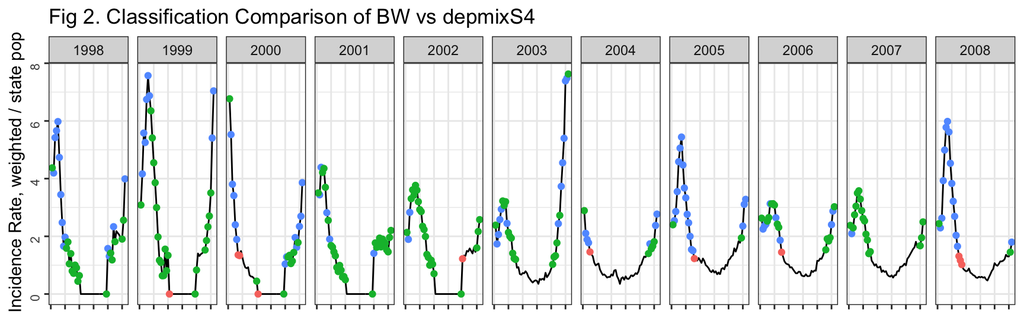

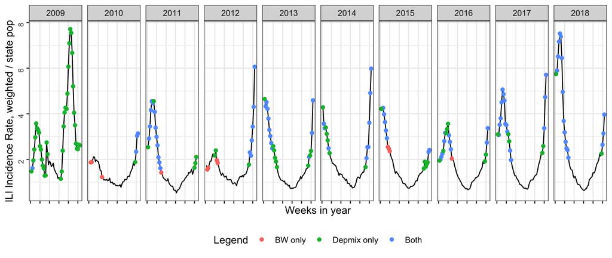